# Rubias self assignments and wintering birds

Eric C. Anderson

Last Updated: 2021-04-01

# Introduction

We use the spatial groups determined in 006 as the reporting units (`repunits`) for genetic stock identification using rubias.

```r
library(tidyverse)
library(rubias)
library(sf)
library(ggspatial)

dir.create("outputs/008", recursive = TRUE, showWarnings = FALSE)
```

# Getting the data

## Get the meta data for the breeding birds

```r
breeding_meta <- read_csv("data/appendices/app1-SITable1_Breed_IndvAssigwgenos.csv")
```

## Get the meta data for the wintering birds

```r
winter_meta <- read_csv("data/appendices/app1-winter-indivs-assignments-and-genos.csv")
```

## Data in rubias format for the wintering birds

This was produced in 007. We get it here:

```r
winter_rubias <- read_rds(file = "outputs/007/winter_rubias.rds")

locus_names <- names(winter_rubias)[seq(5, ncol(winter_rubias), by = 2)]
```

## Data for the breeding sample reference populations

First get the meta data for them and, most importantly the `repunit` of each. We drop the 12 birds from Bishop (BIS) in the reference because they are indeterminate and appear to a mixed population. See 006 for an expanded explanation of this.

```r
breeder_meta <- read_csv("data/appendices/app1-SITable1_Breed_IndvAssigwgenos.csv") %>%
  select(Field_Number, repunit)  %>%
  filter(repunit != "BIS")
```

Now, retrieve the genetic data from the output of 004.

```r
breeder_geno_long <- read_rds(
  file = "outputs/004/rad_and_fluidigm_combined_568_breeders_at_179_snps.rds"
) %>%
  select(Field_Number, CHROMPOS, gene_copy, allele_ACGT)

# filter it down to the 96 loci and pivot it wider an put it into rubias format
breeder96_wide <- breeder_geno_long %>%
  filter(CHROMPOS %in% locus_names) %>%
  pivot_wider(
    names_from = c(CHROMPOS, gene_copy),
    names_sep = ".",
    values_from = allele_ACGT
  )

fni <- seq(2, ncol(breeder96_wide), by = 2)

names(breeder96_wide)[fni] <- str_replace(
  names(breeder96_wide)[fni],
  "\\.1$",
  ""
)
```

And join the genos onto the meta data and add the columns needed to put it in rubias format.

```r
breeder_rubias <- breeder_meta %>%
  left_join(breeder96_wide, by = "Field_Number") %>%
  rename(indiv = Field_Number) %>%
  mutate(
    sample_type = "reference",
    collection = repunit
  ) %>%
  select(sample_type, repunit, collection, indiv, everything())

# finally, get the columns in the same order as winter_rubias
breeder_rubias <- breeder_rubias[, names(winter_rubias)]
```

## Also, get the reference birds at the full 179 loci

```r
breeder179_wide <- breeder_geno_long %>%
  pivot_wider(
    names_from = c(CHROMPOS, gene_copy),
    names_sep = ".",
    values_from = allele_ACGT
  )

fni <- seq(2, ncol(breeder179_wide), by = 2)

names(breeder179_wide)[fni] <- str_replace(
  names(breeder179_wide)[fni],
  "\\.1$",
  ""
)

breeder179_rubias <- breeder_meta %>%
  left_join(breeder179_wide, by = "Field_Number") %>%
  rename(indiv = Field_Number) %>%
  mutate(
    sample_type = "reference",
    collection = repunit
  ) %>%
  select(sample_type, repunit, collection, indiv, everything())
```

# Leave-one-out cross validation

## With the full 179 loci

First, look at how we might have done with the full 179 markers:

```r
breed179_sa <- self_assign(breeder179_rubias, 5, alle_freq_prior = list(const = 0.5))
```

```
## Summary Statistics:
##
## 556 Individuals in Sample
##
## 179 Loci: scaffold1006|size252274--136397, scaffold101|size1699134--364887, scaffold1035|size206130--110619, scaffold1060|size1239554--1066336, scaffold1102|size184380--125163, scaffold1129|size175808--57771, scaffold1129|size175808--76074, scaffold113|size1526484--1253923, scaffold1132|size60963…
##
## 7 Reporting Units: PNW, KER, SCC, INW, SSW, WMT, EST
##
## 7 Collections: PNW, KER, SCC, INW, SSW, WMT, EST
##
## 1.16% of allelic data identified as missing
```

Make a table:

```r
breeding_meta %>%
  select(`final-map-label`, Field_Number) %>%
  left_join(breed179_sa, ., by = c("indiv" = "Field_Number")) %>%
  group_by(`final-map-label`, indiv) %>%
  slice(1) %>%
  ungroup() %>%
  count(`final-map-label`, inferred_repunit) %>%
  pivot_wider(
    names_from = inferred_repunit,
    values_from = n,
    values_fill = list(n = 0L)
  ) %>%
  select(
    `final-map-label`,
    PNW,
    KER,
    SCC,
    INW,
    SSW,
    WMT,
    EST
  )
```

| final-map-label | PNW | KER | SCC | INW | SSW | WMT | EST |
| --- | --- | --- | --- | --- | --- | --- | --- |
| 1 | 17 | 0 | 0 | 0 | 0 | 0 | 0 |
| 2 | 51 | 0 | 0 | 0 | 0 | 0 | 1 |
| 3 | 10 | 0 | 0 | 0 | 0 | 0 | 0 |
| 4 | 5 | 25 | 0 | 1 | 0 | 0 | 0 |
| 6 | 0 | 0 | 4 | 2 | 0 | 0 | 0 |
| 7 | 0 | 1 | 15 | 0 | 1 | 0 | 0 |
| 8 | 0 | 0 | 0 | 5 | 0 | 0 | 0 |
| 9 | 0 | 0 | 0 | 13 | 0 | 0 | 0 |
| 10 | 0 | 0 | 0 | 6 | 0 | 0 | 0 |
| 11 | 1 | 0 | 0 | 2 | 0 | 0 | 0 |

[output cut: 26 more lines]

## The same with the 96 SNPs

We want to assess how accurately we can assign individuals to their genoscape repunit of origin.

```r
breed_sa <- self_assign(breeder_rubias, 5)
```

```
## Summary Statistics:
##
## 556 Individuals in Sample
##
## 96 Loci: scaffold101|size1699134--364887, scaffold1035|size206130--110619, scaffold1102|size184380--125163, scaffold1129|size175808--57771, scaffold1129|size175808--76074, scaffold113|size1526484--1253923, scaffold12|size2584012--1685287, scaffold1296|size145063--76502, scaffold1310|size247655--4…
##
## 7 Reporting Units: PNW, KER, SCC, INW, SSW, WMT, EST
##
## 7 Collections: PNW, KER, SCC, INW, SSW, WMT, EST
##
## 0.96% of allelic data identified as missing
```

Now, look at numbers of correct/incorrect assignment. For this we want to join the population number to each individual.

```r
breeding_meta %>%
  select(`final-map-label`, Field_Number) %>%
  left_join(breed_sa, ., by = c("indiv" = "Field_Number")) %>%
  group_by(`final-map-label`, indiv) %>%
  slice(1) %>%
  ungroup() %>%
  count(`final-map-label`, inferred_repunit) %>%
  pivot_wider(
    names_from = inferred_repunit,
    values_from = n,
    values_fill = list(n = 0L)
  ) %>%
  select(
    `final-map-label`,
    PNW,
    KER,
    SCC,
    INW,
    SSW,
    WMT,
    EST
  )
```

| final-map-label | PNW | KER | SCC | INW | SSW | WMT | EST |
| --- | --- | --- | --- | --- | --- | --- | --- |
| 1 | 17 | 0 | 0 | 0 | 0 | 0 | 0 |
| 2 | 47 | 3 | 1 | 1 | 0 | 0 | 0 |
| 3 | 5 | 1 | 1 | 3 | 0 | 0 | 0 |
| 4 | 6 | 21 | 4 | 0 | 0 | 0 | 0 |
| 6 | 0 | 0 | 5 | 1 | 0 | 0 | 0 |
| 7 | 0 | 0 | 16 | 0 | 1 | 0 | 0 |
| 8 | 0 | 0 | 0 | 5 | 0 | 0 | 0 |
| 9 | 1 | 0 | 0 | 12 | 0 | 0 | 0 |
| 10 | 0 | 0 | 0 | 6 | 0 | 0 | 0 |
| 11 | 2 | 0 | 0 | 1 | 0 | 0 | 0 |

[output cut: 26 more lines]

That is the result that is in S1-Table 1.

# Now assign the wintering birds

```r
set.seed(15)
winter_assig <- infer_mixture(
  reference = breeder_rubias,
  mixture = winter_rubias,
  gen_start_col = 5
)

# get the maximum a-posterior (MAP) assignments
winter_MAP <- winter_assig$indiv_posteriors %>%
  arrange(indiv, desc(PofZ)) %>%
  group_by(indiv) %>%
  slice(1)
```

Check that this is congruent with the appendix:

```r
winter_MAP %>%
  left_join(
    winter_meta %>% select(Field_Number, Assignment),
    by = c("indiv" = "Field_Number")
    ) %>%
  ungroup() %>%
  count(repunit == Assignment)
```

| repunit == Assignment | n |
| --- | --- |
| TRUE | 363 |

As it is showing 363 TRUEs, that means that the assignments listed in appendix S1 are correct.

# finally, put those points on a map

```r
# get assignments and add Lat-Longs and then jitter them a little
set.seed(100)
winter_points <- winter_MAP %>%
  select(indiv, repunit) %>%
  left_join(
    winter_meta %>% select(Field_Number, Lat, Long),
    by = c("indiv" = "Field_Number")
  ) %>%
  mutate(
    jitLat = Lat + runif(n(), min = -0.5, max = 0.5 ),
    jitLong = Long + runif(n(), min = -0.5, max = 0.5 )
  ) %>%
  group_by(repunit) %>%
  mutate(n_in_repu = n()) %>%
  arrange(desc(n_in_repu))

# note that we arranged these so the last ones (and hopefully, thus, the
# ones plotted on top) are from the least frequent repunits.
```

Make a simple basemap with Natural Earth data:

```r
domain <- c(
  xmin = -125,
  xmax = -60,
  ymin = -2,
  ymax = 30
)
coast_cropped <- st_read("geo-spatial/ne_10m_coastline/ne_10m_coastline.shp") %>%
  st_crop(domain)
countries_cropped <-  st_read("geo-spatial/ne_10m_admin_0_boundary_lines_land/ne_10m_admin_0_boundary_lines_land.shp") %>%
  st_crop(domain)
states_cropped <- st_read("geo-spatial/ne_10m_admin_1_states_provinces_lines/ne_10m_admin_1_states_provinces_lines.shp") %>%
  st_crop(domain)
```

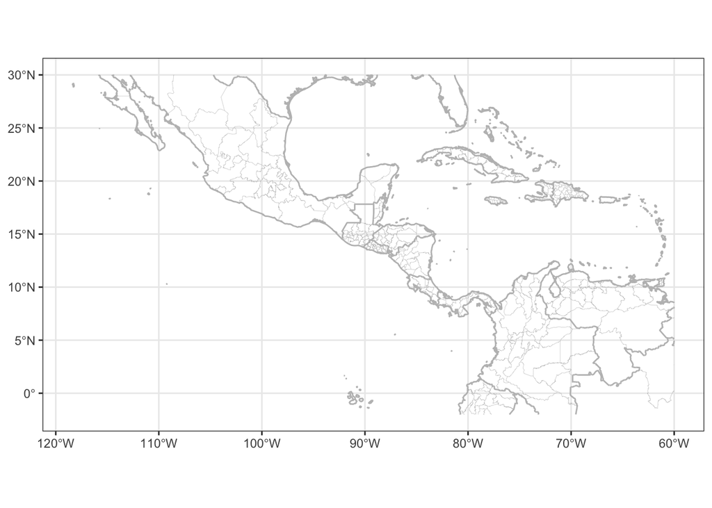

```r
basemap <- ggplot() +
  geom_sf(data = coast_cropped, colour = "gray") +
  geom_sf(data = countries_cropped, colour = "gray", fill = NA) +
  geom_sf(data = states_cropped, colour = "gray", fill = NA, size = 0.1) +
  theme_bw()

basemap
```

Then add some points to that

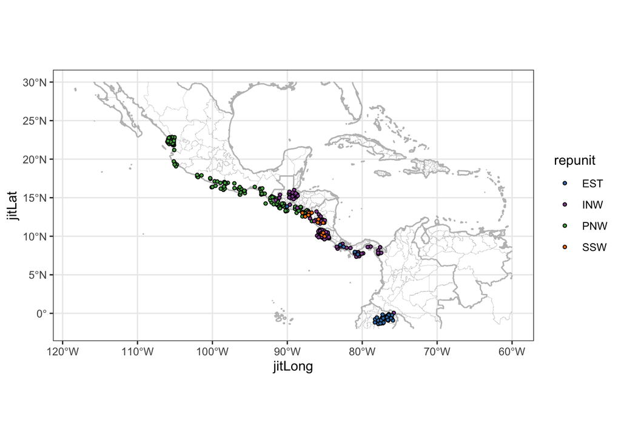

```r
source("R/colors.R")
basemap + geom_spatial_point(
    data = winter_points,
    mapping = aes(x = jitLong, y = jitLat, fill = repunit),
    size = 1,
    shape = 21,
  ) +
  scale_fill_manual(values = cluster_colors)
```

That gives a nice picture. For the final figure in the paper, the points were moved around by hand so that each was was maximally visible, and, of course, the Natural Earth rasters were used as a background as described in 006.

# Running Time

Running the code and rendering this notebook required approximately this much time on a Mac laptop of middling speed, listed in `HH:MM:SS`.

```r
td <- Sys.time() - start_time
tdf <- hms::as_hms(ceiling(hms::as_hms(td)))
dir.create("stored_run_times", showWarnings = FALSE, recursive = TRUE)
write_rds(tdf, "stored_run_times/008.rds")
tdf
```

```
## 00:00:11
```

A quick note about the repository. The the output from this just gets stored in `./data/appendices/app1-winter-indivs-assignments-and-genos.csv` as it is more accessible to users that way (and it can be part of the supp info, if desired).

[session information not shown]